# APPDS - Statistics

HW 4 - 2022/11/17 - Schelander Martina

## Table of Contents

1. Exercise 33
2. Exercise 34
3. Exercise 36
4. Exercise 37
5. Exercise 38
6. Exercise 39
7. Exercise 41
8. Exercise 42
9. Exercise 43
10. Exercise 46
11. Exercise 49
12. Exercise 50

Prerequisites - Load libraries

```r
library(dplyr)
library(mosaic)
library(vcd)
library(vcdExtra)
library(tidyverse)
library(gridExtra)
library(knitr)
library(latex2exp)
```

## Exercise 33

A hardware store buys ceramic tiles from three producers, A, B and C. The manager of the hardware store draws a sample of 1000 ceramic tiles per producer and determines the numbers of erroneous ceramic tiles:  
- Producer A: 41 erroneous ceramic tiles  
- Producer B: 21 erroneous ceramic tiles  
- Producer C: 55 erroneous ceramic tiles  
Do the producers deliver ceramic tiles of equal quality? α = 1%

### Data Visualization

```r
Data_Exc33 <- matrix(c(41, 21, 55, 1000 - 41, 1000 - 21, 1000 - 55), ncol=2)
dimnames(Data_Exc33) <- list(Producers = c("A", "B", "C"), Tiles = c("errors", "not errors"))
kable(Data_Exc33)
```

|  | errors | not errors |
| --- | --- | --- |
| A | 41 | 959 |
| B | 21 | 979 |
| C | 55 | 945 |

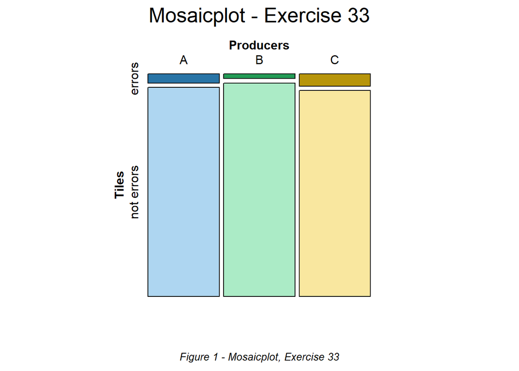

```r
vcd::mosaic(Data_Exc33, main = "Mosaicplot - Exercise 33", sub = 'Figure 1 - Mosaicplot, Exercise 33', sub_gp = gpar(fontface = "italic",fontsize = 10), color = TRUE, shade = TRUE, direction=c("v","h"),gp = gpar(fill=c('#2874A6', '#239B56', '#B7950B', '#AED6F1', '#ABEBC6', '#F9E79F')))
```

### Step 1: Formulate Hypotheses

| Null Hypothesis | Alternative Hypothesis |
| --- | --- |
| All producers deliver the same quality of tiles. | Not all producers deliver the same quality of tiles. |

#### Approach:

Since the single variable is nominal [error/no error], the observations are given as frequencies and we observe independent samples a Chi-Squared Test is the appropriate approach in this case.

### Step 2: Calculate Test Statistics

| Average Error Rate | Average No Error Rate |
| --- | --- |
| (41+21+55)/3000 = **0.039** | (959+979+945)/3000 = **0.961** |

Check for Validity: 0.961 + 0.039 = 1

|  | Observed Errors | Expected Errors | Observed OK | Expected OK |
| --- | --- | --- | --- | --- |
| Producer A | 41 | 1000*0.039 = 39 | 959 | 1000*0.961 = 961 |
| Producer B | 21 | 1000*0.039 = 39 | 979 | 1000*0.961 = 961 |
| Producer C | 55 | 1000*0.039 = 39 | 945 | 1000*0.961 = 961 |

X<sup>2</sup><sub>obs</sub>= Σ((Observed-Expected)<sup>2</sup>/Expected)

(41-39)<sup>2</sup>/39 + (21-39)<sup>2</sup>/39 + (55-39)<sup>2</sup>/39 + (959-961)<sup>2</sup>/961 + (979-961)<sup>2</sup>/961 + (945-961)<sup>2</sup>/961

=**15,58205**

#### Calculation in R

Column overall means for errors

```r
errors_producer <- sum(Data_Exc33[, "errors"]) / sum(Data_Exc33)
errors_producer
```

```
## [1] 0.039
```

Column overall means for non errors

```r
not_errors_producer <- sum(Data_Exc33[, "not errors"])/sum(Data_Exc33)
not_errors_producer
```

```
## [1] 0.961
```

Sum validation

```r
sum = errors_producer + not_errors_producer
sum
```

```
## [1] 1
```

### Calculation in R

```r
expected <- c((Data_Exc33[, "errors"] + Data_Exc33[, "not errors"]) * errors_producer,(Data_Exc33[, "errors"] + Data_Exc33[, "not errors"]) * not_errors_producer)
```

Expected Values

```r
table_expected <- matrix(expected, ncol=2)
dimnames(table_expected) <- list(producer = c("Producer A", "Producer B", "Producer C"),produced = c("[errors]", "[not errors]"))
table_expected
```

```
##             produced
## producer     [errors] [not errors]
##   Producer A       39          961
##   Producer B       39          961
##   Producer C       39          961
```

Test Statistic

```r
x <- sum((Data_Exc33 - expected)^2 / expected)
x
```

```
## [1] 15.58206
```

### Step 3: Determine the critical value

f = sample size(3 Producers) - 1 = 2 degrees of freedom

X<sup>2</sup>-distribution with df=2 and prop=0.99:

lower.tail = FALSE so we can use α=0.01 for prop=0.99

```r
alpha <- 0.01
df <- 2
crit_val <- qchisq(alpha, df, lower.tail = FALSE)
crit_val
```

```
## [1] 9.21034
```

Critical value X<sup>2</sup><sub>f;1-α</sub> = **9.21034**

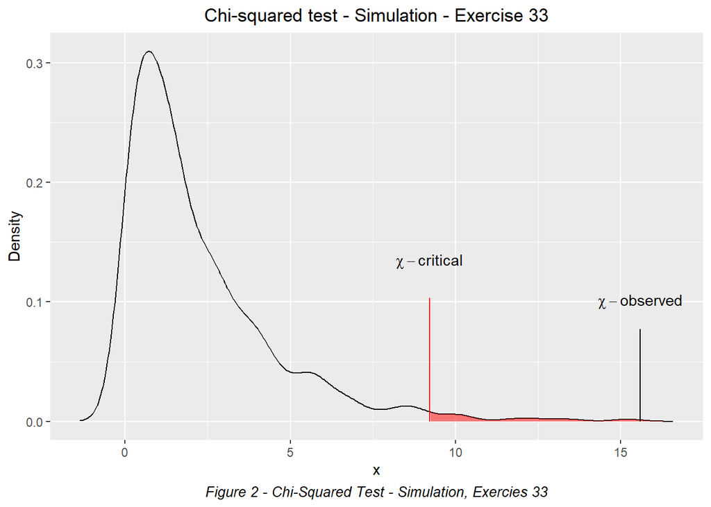

```r
plot_chisq <- function(sim_data, x, crit_val, title = "Chi-squared test - Simulation - Exercise 33"
) {
annotation_y_val <- max(sim_data$y) * 1/3
annotation_y_val2 <- max(sim_data$y) * 1/4
plt <- ggplot(sim_data, aes(x, y)) + ggtitle(title) + labs(y = "Density", caption = "Figure 2 - Chi-Squared Test - Simulation, Exercies 33") + geom_line() + geom_area(data = subset(sim_data, x >= crit_val),fill = "red", alpha = 0.5) + annotate("segment", x = crit_val, xend = crit_val,y = 0, yend = annotation_y_val,color = "red") + annotate("text",x = crit_val, y =annotation_y_val * 1.3,label = "chi-critical", parse = TRUE) + annotate("segment", x = x, xend = x,y = 0, yend = annotation_y_val2,color = "black") + annotate("text",x = x, y = annotation_y_val2 * 1.3, label = "chi-observed", parse = TRUE)+theme(plot.caption = element_text(color = "black", face = "italic", hjust = 0.5, size
= 10))+theme(plot.title = element_text(hjust = 0.5))

return(plt)}

sim_data <- data.frame(density(rchisq(500, df))[c("x", "y")])
plot_chisq(sim_data, x, crit_val)
```

```r
p_value <- 1 - pchisq(x, df)
p_value
```

```
## [1] 0.000413427
```

### Step 4: Result

for α = 0.01 = X<sup>2</sup><sub>obs</sub> > X<sup>2</sup><sub>f;1-α</sub>

**15,58205 > 9.21034 ⇒ Reject H<sub>0</sub>**

## Exercise 34

A hardware store buys plastic bags from three producers, A, B and C. The manager of the hardware store draws draws different samples per producer and determines the numbers of broken plastic bags:  
Producer A: 6 broken plastic bags out of 125 samples  
Producer B: 17 broken plastic bags out of 200 samples  
Producer C: 10 broken plastic bags out of 325 samples  
Do the producers deliver plastic bags of equal quality? α = 1% and α = 5%

### Data Visualization

```r
Data_Exc34 <- matrix(c(6, 17, 10, 125 - 6, 200 - 17, 325 - 10), ncol=2)
dimnames(Data_Exc34) <- list(Producers = c("A", "B", "C"), Bags = c("errors", "not errors"))
kable(Data_Exc34)
```

|  | errors | not errors |
| --- | --- | --- |
| A | 6 | 119 |
| B | 17 | 183 |
| C | 10 | 315 |

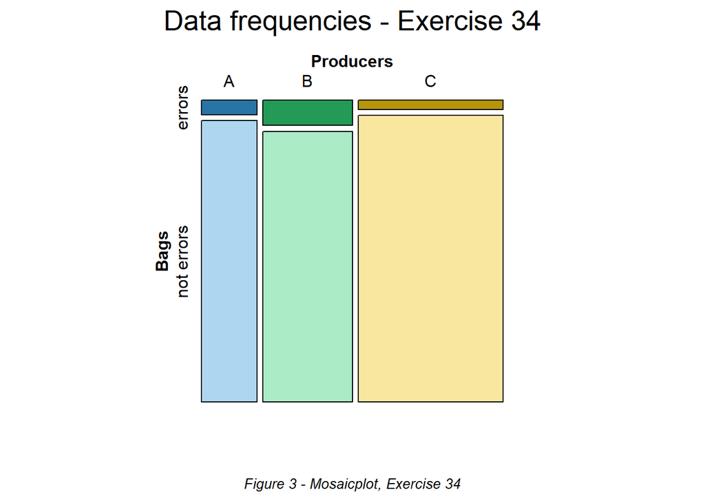

```r
vcd::mosaic(Data_Exc34, main = "Data frequencies - Exercise 34", sub = 'Figure 3 - Mosaicplot, Exercise 34', sub_gp = gpar(fontface = "italic",fontsize = 10), color = TRUE, shade = TRUE, direction=c("v","h"), gp = gpar(fill=c('#2874A6', '#239B56', '#B7950B', '#AED6F1', '#ABEBC6', '#F9E79F')))
```

### Step 1: Formulate Hypotheses

| Null Hypothesis | Alternative Hypothesis |
| --- | --- |
| All producers deliver the same quality of plastic bags. | Not all producers deliver the same quality of plastic bags. |

#### Approach:

Since the single variable is nominal [error/no error], the observations are given as frequencies and we observe independent samples a Chi-Squared Test is the appropriate approach in this case.

### Step 2: Calculate Test Statistics

| Average Error Rate | Average No Error Rate |
| --- | --- |
| (6+17+10)/(125+200+325) = **0.05077** | (119+183+315)/(125+200+325) = **0.94923** |

Check for Validity: 0.05077 + 0.94923 = 1

|  | Observed Errors | Expected Errors | Observed OK | Expected OK |
| --- | --- | --- | --- | --- |
| Producer A | 6 | 125*0.05077 = 6,34625 | 119 | 125*0.94923 = 118,65 |
| Producer B | 17 | 200*0.05077 = 10,15 | 183 | 200*0.94923 = 189,84 |
| Producer C | 10 | 325*0.05077 = 16,5 | 315 | 325*0.94923 = 308,49 |

X<sup>2</sup><sub>obs</sub>= Σ((Observed-Expected)<sup>2</sup>/Expected)

(6-6,34625)<sup>2</sup>/6,34625 + (17-10,15)<sup>2</sup>/10,15 + (10-16,5)<sup>2</sup>/16,5 + (119-118,65)<sup>2</sup>/118,65 + (183-189,84)<sup>2</sup>/189,84 + (315-308,49)<sup>2</sup>/308,49

=**7.587263**

#### Calculation in R

Column overall means for errors

```r
errors_producer <- sum(Data_Exc34[, "errors"]) / sum(Data_Exc34)
errors_producer
```

```
## [1] 0.05076923
```

Column overall means for non errors

```r
not_errors_producer <- sum(Data_Exc34[, "not errors"])/sum(Data_Exc34)
not_errors_producer
```

```
## [1] 0.9492308
```

Sum validation

```r
sum = errors_producer + not_errors_producer
sum
```

```
## [1] 1
```

### Calculation in R

```r
expected <- c((Data_Exc34[, "errors"] + Data_Exc34[, "not errors"]) * errors_producer,(Data_Exc34[, "errors"] + Data_Exc34[, "not errors"]) * not_errors_producer)
```

Expected Values

```r
table_expected <- matrix(expected, ncol=2)
dimnames(table_expected) <- list(producer = c("Producer A", "Producer B", "Producer C"),produced = c("errors", "not errors"))
table_expected
```

```
##             produced
## producer        errors not errors
##   Producer A  6.346154   118.6538
##   Producer B 10.153846   189.8462
##   Producer C 16.500000   308.5000
```

Test Statistic

```r
x <- sum((Data_Exc34 - expected)^2 / expected)
x
```

```
## [1] 7.580301
```

### Step 3: Determine the critical value

f = sample size(3 Producers) - 1 = 2 degrees of freedom

X<sup>2</sup>-distribution with df=2 and α=0.01

lower.tail = FALSE so we can use α=0.01

```r
alpha <- 0.01
df <- 2
crit_val <- qchisq(alpha, df, lower.tail = FALSE)
crit_val
```

```
## [1] 9.21034
```

Critical value X<sup>2</sup><sub>f;1-α</sub> = **9.21034**

X<sup>2</sup>-distribution with df=2 and α=0.05

```r
alpha <- 0.05
df <- 2
crit_val <- qchisq(alpha, df, lower.tail = FALSE)
crit_val
```

```
## [1] 5.991465
```

Critical value X<sup>2</sup><sub>f;1-α</sub> = **5.991465**

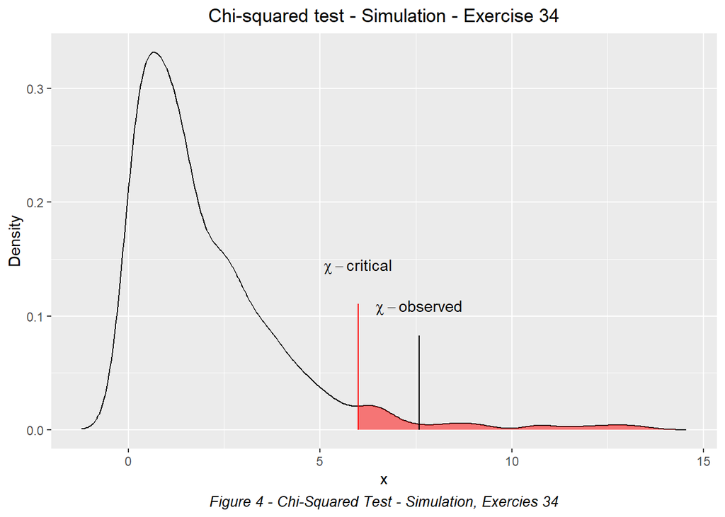

```r
plot_chisq <- function(sim_data, x, crit_val, title = "Chi-squared test - Simulation - Exercise 34"
) {
annotation_y_val <- max(sim_data$y) * 1/3
annotation_y_val2 <- max(sim_data$y) * 1/4
plt <- ggplot(sim_data, aes(x, y)) + ggtitle(title) + labs(y = "Density", caption="Figure 4 - Chi-Squared Test - Simulation, Exercies 34") + geom_line() + geom_area(data = subset(sim_data, x >= crit_val),fill = "red", alpha = 0.5) + annotate("segment", x = crit_val, xend = crit_val,y = 0, yend = annotation_y_val,color = "red") + annotate("text",x = crit_val, y =annotation_y_val * 1.3,label = "chi-critical", parse = TRUE) + annotate("segment", x = x, xend = x,y = 0, yend = annotation_y_val2,color = "black") + annotate("text",x = x, y = annotation_y_val2 * 1.3, label = "chi-observed", parse = TRUE)+theme(plot.caption = element_text(color = "black", face = "italic", hjust = 0.5, size
= 10))+theme(plot.title = element_text(hjust = 0.5))
return(plt)}

sim_data <- data.frame(density(rchisq(500, df))[c("x", "y")])
plot_chisq(sim_data, x, crit_val)
```

```r
p_value <- 1 - pchisq(x, df)
p_value
```

```
## [1] 0.02259221
```

### Step 4: Result

for α = 0.01 = X<sup>2</sup><sub>obs</sub> > X<sup>2</sup><sub>f;1-α</sub>

**7.587263 < 9.21034 ⇒ Keep H<sub>0</sub>**

for α = 0.05 = X<sup>2</sup><sub>obs</sub> > X<sup>2</sup><sub>f;1-α</sub>

**7.587263 > 5.991465 ⇒ Reject H<sub>0</sub>**

## Exercise 36

Young adults were asked about their satisfaction with their own character and their own family situation.

|  | Family OK | Family not OK |
| --- | --- | --- |
| Happy with own character | 11 | 107 |
| Unhappy with own character | 60 | 94 |

Use a Chi-squared test to determine whether there was a connection between these two variables.  
1: α = 1%  
2: α = 5% </p)

### Data Visualization

```r
Data_Exc36 <- matrix(c(11, 60, 107, 94), ncol=2)
dimnames(Data_Exc36) <- list("Happyness with own character" = c("Happy with own character", "Unhappy with own character"), Famliy = c("Family OK", "Family not OK"))
kable(Data_Exc36)
```

|  | Family OK | Family not OK |
| --- | --- | --- |
| Happy with own character | 11 | 107 |
| Unhappy with own character | 60 | 94 |

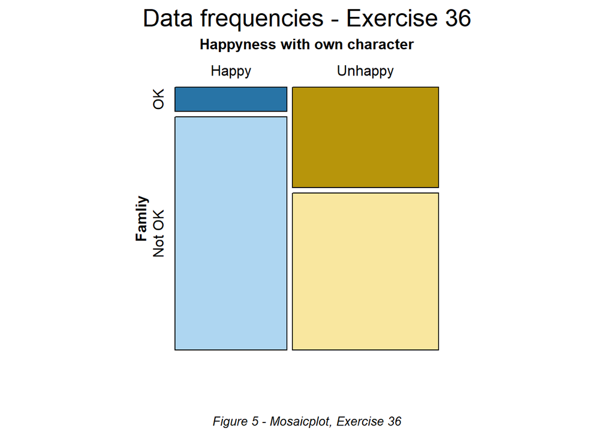

```r
dimnames(Data_Exc36) <- list("Happyness with own character" = c("Happy", "Unhappy"), Famliy = c("OK", "Not OK"))
vcd::mosaic(Data_Exc36, main = "Data frequencies - Exercise 36", sub = 'Figure 5 - Mosaicplot, Exercise 36', sub_gp = gpar(fontface = "italic",fontsize = 10), color = TRUE, shade = TRUE, direction=c("v","h"), gp = gpar(fill=c('#2874A6', '#B7950B', '#AED6F1', '#F9E79F')), labeling= labeling_border(rot_labels = c(0,0,0,90),offset_varnames = c(0.5,0.5,0,0)
      ))
```

### Step 1: Formulate Hypotheses

| Null Hypothesis | Alternative Hypothesis |
| --- | --- |
| People coming from different Familiy situations (OK/NOK) are equally happy. There is not connection between the two variables, [Family OK/Not Ok] and [Happy / Unhappy with own character] | There is a connection between the two variables. |

#### Approach:

Since the variables in consideration are nominal [Happy/Unhappy] and [Family OK/Family Not OK], the observations are given as frequencies and we observe independent samples a Chi-Squared Fourfold Test is the appropriate approach in this case.

### Step 2: Calculate Test Statistics

```r
numerator <- sum(Data_Exc36)*(11*94-60*107)^2
numerator
```

```
## [1] 7890446912
```

```r
denominator <- sum(Data_Exc36["Happy", ])*sum(Data_Exc36["Unhappy", ])*sum(Data_Exc36[ ,"OK"])*sum(Data_Exc36[ ,"Not OK"])
denominator
```

```
## [1] 259332612
```

```r
test_statistics_Exc36 <- numerator / denominator
test_statistics_Exc36
```

```
## [1] 30.42597
```

So the observed valuer is X<sup>2</sup><sub>obs</sub>=**30.42597**

### Step 3: Determine the critical value

f = sample size-1 = 2-1 = 1 degrees of freedom

X<sup>2</sup>-distribution with df=1, prop=0.99 and α=0.01

lower.tail = FALSE so we can use α=0.01

```r
alpha <- 0.01
df <- 1
crit_val <- qchisq(alpha, df, lower.tail = FALSE)
crit_val
```

```
## [1] 6.634897
```

Critical value X<sup>2</sup><sub>f;1-α</sub> = **6.634897**

X<sup>2</sup>-distribution with df=1, prop=0.95 and α=0.05

```r
alpha <- 0.05
df <- 1
crit_val <- qchisq(alpha, df, lower.tail = FALSE)
crit_val
```

```
## [1] 3.841459
```

Critical value X<sup>2</sup><sub>f;1-α</sub> = **3.841459**

### Step 4: Result

for α = 0.01 = X<sup>2</sup><sub>obs</sub> > X<sup>2</sup><sub>f;1-α</sub>

**30.42597 > 6.634897 ⇒ Reject H<sub>0</sub>**

for α = 0.05 = X<sup>2</sup><sub>obs</sub> > X<sup>2</sup><sub>f;1-α</sub>

**30.42597 > 3.841459 ⇒ Reject H<sub>0</sub>**

## Exercise 37

70 engineers and 30 sales men applied for a certain job position. The company categorized them into two classes: ’suitable’ and ’unsuitable’.

|  | suitable | unsuitable |
| --- | --- | --- |
| Engineer | 34 | 36 |
| Sales man | 26 | 4 |

Use a Chi-squared test to determine whether there was a connection between these two variables.  
1: α = 1%  
2: α = 5% </p)

### Data Visualization

```r
Data_Exc37 <- matrix(c(34, 26, 36, 4), ncol=2)
dimnames(Data_Exc37) <- list("Applicant Type" = c("Engineer", "Sales man"), Suitability = c("suitable", "unsuitable"))
kable(Data_Exc37)
```

|  | suitable | unsuitable |
| --- | --- | --- |
| Engineer | 34 | 36 |
| Sales man | 26 | 4 |

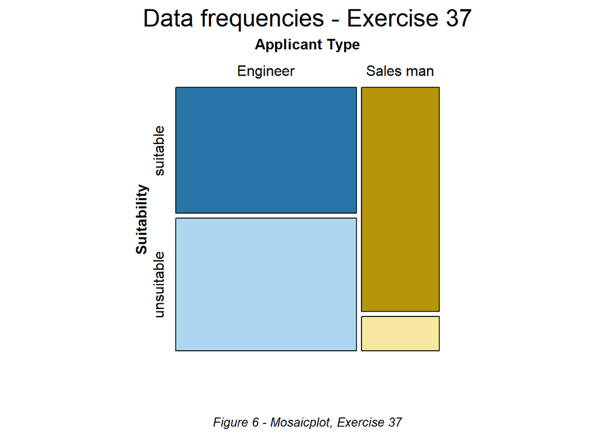

```r
vcd::mosaic(Data_Exc37, main = "Data frequencies - Exercise 37", sub = 'Figure 6 - Mosaicplot, Exercise 37', sub_gp = gpar(fontface = "italic",fontsize = 10), color = TRUE, shade = TRUE, direction=c("v","h"), gp = gpar(fill=c('#2874A6', '#B7950B', '#AED6F1', '#F9E79F')), labeling= labeling_border(rot_labels = c(0,0,0,90),offset_varnames = c(0.5,0.5,0,0)
      ))
```

### Step 1: Formulate Hypotheses

| Null Hypothesis | Alternative Hypothesis |
| --- | --- |
| There is not connection between the two variables, profession and suitability for the job position considered in this example. | There is a connection between the two variables. The profession and the suitability for the job position are related. |

#### Approach:

Since the variables in consideration are nominal [suitable/not suitable] [Engineer/Sales man], the observations are given as frequencies and we observe independent samples a Chi-Squared Fourfold Test is the appropriate approach in this case.

### Step 2: Calculate Test Statistics

```r
numerator <- sum(Data_Exc37)*(34*4-26*36)^2
numerator
```

```
## [1] 6.4e+07
```

```r
denominator <- sum(Data_Exc37["Engineer", ])*sum(Data_Exc37["Sales man", ])*sum(Data_Exc37[ ,"suitable"])*sum(Data_Exc37[ ,"unsuitable"])
denominator
```

```
## [1] 5040000
```

```r
test_statistics_Exc37 <- numerator / denominator
test_statistics_Exc37
```

```
## [1] 12.69841
```

So the observed value is X<sup>2</sup><sub>obs</sub>=**12.69841**

### Step 3: Determine the critical value

f = sample size-1 = 2-1 = 1 degree of freedom

X<sup>2</sup>-distribution with df=1, prop=0.99 and α=0.01

lower.tail = FALSE so we can use α=0.01

```r
alpha <- 0.01
df <- 1
crit_val <- qchisq(alpha, df, lower.tail = FALSE)
crit_val
```

```
## [1] 6.634897
```

Critical value X<sup>2</sup><sub>f;1-α</sub> = **6.634897**

X<sup>2</sup>-distribution with df=1, prop=0.95 and α=0.05

```r
alpha <- 0.05
df <- 1
crit_val <- qchisq(alpha, df, lower.tail = FALSE)
crit_val
```

```
## [1] 3.841459
```

Critical value X<sup>2</sup><sub>f;1-α</sub> = **3.841459**

### Step 4: Result

for α = 0.01 = X<sup>2</sup><sub>obs</sub> > X<sup>2</sup><sub>f;1-α</sub>

**12.69841 > 6.634897 ⇒ Reject H<sub>0</sub>**

for α = 0.05 = X<sup>2</sup><sub>obs</sub> > X<sup>2</sup><sub>f;1-α</sub>

**12.69841 > 3.841459 ⇒ Reject H<sub>0</sub>**

## Exercise 38

70 engineers and 30 sales men applied for a certain job position. The company categorized them into two classes: ’suitable’ and ’unsuitable’.

|  | suitable | unsuitable |
| --- | --- | --- |
| Engineer | 48 | 22 |
| Sales man | 20 | 10 |

Use a Chi-squared test to determine whether there was a connection between these two variables.  
1: α = 1%  
2: α = 5% </p)

### Data Visualization

```r
Data_Exc38 <- matrix(c(48, 20, 22, 10), ncol=2)
dimnames(Data_Exc38) <- list("Applicant Type" = c("Engineer", "Sales man"), Suitability = c("suitable", "unsuitable"))
kable(Data_Exc38)
```

|  | suitable | unsuitable |
| --- | --- | --- |
| Engineer | 48 | 22 |
| Sales man | 20 | 10 |

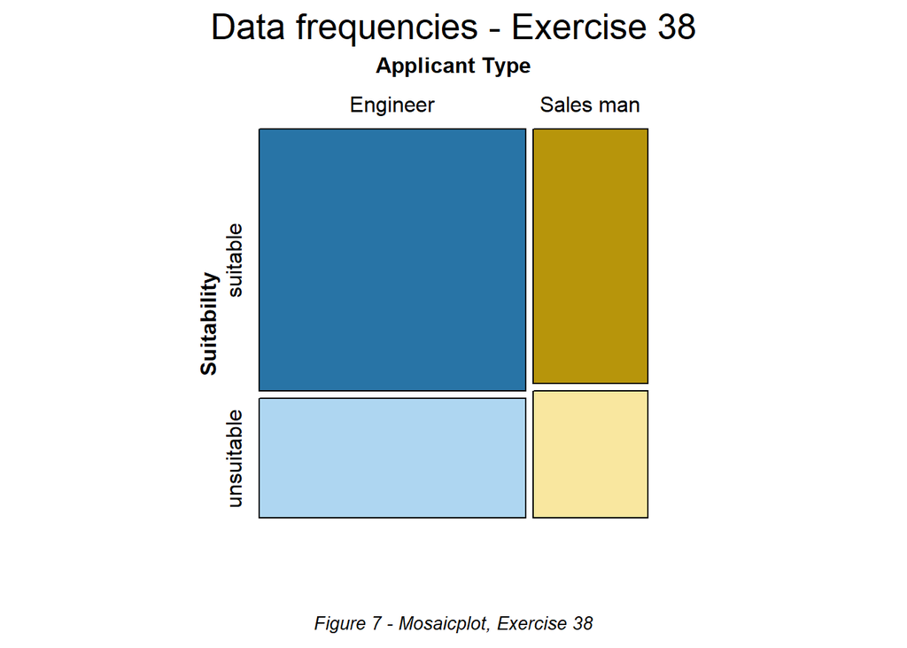

```r
vcd::mosaic(Data_Exc38, main = "Data frequencies - Exercise 38", sub = 'Figure 7 - Mosaicplot, Exercise 38', sub_gp = gpar(fontface = "italic",fontsize = 10), color = TRUE, shade = TRUE, direction=c("v","h"), gp = gpar(fill=c('#2874A6', '#B7950B', '#AED6F1', '#F9E79F')), labeling= labeling_border(rot_labels = c(0,0,0,90),offset_varnames = c(0.5,0.5,0,0)
      ))
```

### Step 1: Formulate Hypotheses

| Null Hypothesis | Alternative Hypothesis |
| --- | --- |
| There is not connection between the two variables, profession and suitability for the job position considered in this example. | There is a connection between the two variables. The profession and the suitability for the job position are related. |

#### Approach:

Since the variables in consideration are nominal [suitable/not suitable] [Engineer/Sales man], the observations are given as frequencies and we observe independent samples a Chi-Squared Fourfold Test is the appropriate approach in this case.

### Step 2: Calculate Test Statistics

```r
numerator <- sum(Data_Exc38)*(48*10-20*22)^2
numerator
```

```
## [1] 160000
```

```r
denominator <- sum(Data_Exc38["Engineer", ])*sum(Data_Exc38["Sales man", ])*sum(Data_Exc38[ ,"suitable"])*sum(Data_Exc38[ ,"unsuitable"])
denominator
```

```
## [1] 4569600
```

```r
test_statistics_Exc38 <- numerator / denominator
test_statistics_Exc38
```

```
## [1] 0.03501401
```

So the observed value is X<sup>2</sup><sub>obs</sub>=**0.03501401**

### Step 3: Determine the critical value

f = sample size-1 = 2-1 = 1 degree of freedom

X<sup>2</sup>-distribution with df=1, prop=0.99 and α=0.01

lower.tail = FALSE so we can use α=0.01

```r
alpha <- 0.01
df <- 1
crit_val <- qchisq(alpha, df, lower.tail = FALSE)
crit_val
```

```
## [1] 6.634897
```

Critical value X<sup>2</sup><sub>f;1-α</sub> = **6.634897**

X<sup>2</sup>-distribution with df=1, prop=0.95 and α=0.05

```r
alpha <- 0.05
df <- 1
crit_val <- qchisq(alpha, df, lower.tail = FALSE)
crit_val
```

```
## [1] 3.841459
```

Critical value X<sup>2</sup><sub>f;1-α</sub> = **3.841459**

## Exercise 39

Use the dataset ’tips’.  
Is there an association between smoking and the time of the day (lunch or dinner)?

### Load the dataset

```r
tips<-read.csv2("C:\\_Privat\\_MSC_\\Skripten und Hü\\Statistics\\HW\\tips.csv")
```

```r
str(tips)
```

```
## 'data.frame':    244 obs. of  7 variables:
##  $ total_bill: num  17 10.3 21 23.7 24.6 ...
##  $ tip       : num  1.01 1.66 3.5 3.31 3.61 4.71 2 3.12 1.96 3.23 ...
##  $ sex       : chr  "Female" "Male" "Male" "Male" ...
##  $ smoker    : chr  "No" "No" "No" "No" ...
##  $ day       : chr  "Sun" "Sun" "Sun" "Sun" ...
##  $ time      : chr  "Dinner" "Dinner" "Dinner" "Dinner" ...
##  $ size      : int  2 3 3 2 4 4 2 4 2 2 ...
```

```r
tally(~smoker | time, data = tips)
```

```
##       time
## smoker Dinner Lunch
##    No     106    45
##    Yes     70    23
```

### Data Visualization

```r
matrix_smoker_time <- tally(~smoker | time, data = tips)
Data_Exc39 <- matrix(c(matrix_smoker_time), ncol=2)
dimnames(Data_Exc39) <- list(Smoker = c("No", "Yes"),"Time of Day" = c("Dinner", "Lunch"))
kable(Data_Exc39)
```

|  | Dinner | Lunch |
| --- | --- | --- |
| No | 106 | 45 |
| Yes | 70 | 23 |

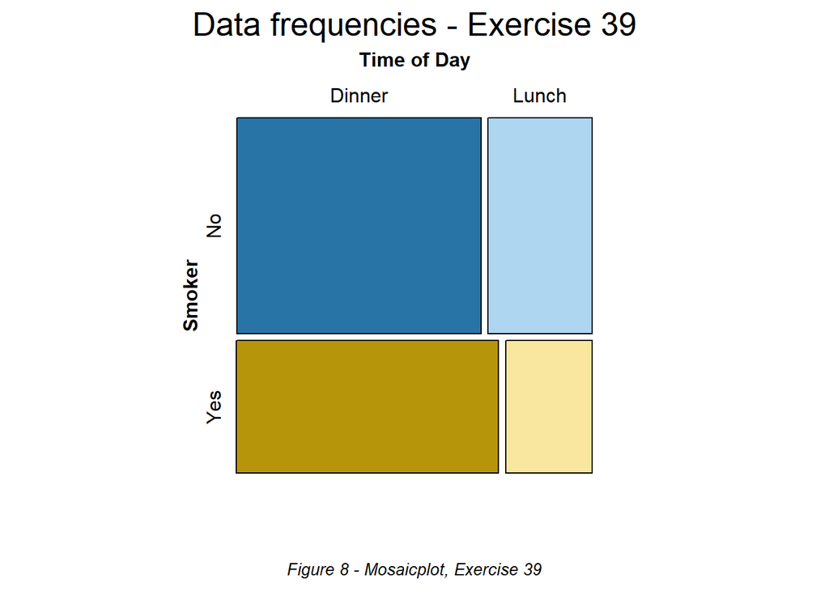

```r
vcd::mosaic(Data_Exc39, main = "Data frequencies - Exercise 39", sub = 'Figure 8 - Mosaicplot, Exercise 39', sub_gp = gpar(fontface = "italic",fontsize = 10), color = TRUE, shade = TRUE, direction=c("h","v"), gp = gpar(fill=c('#2874A6', '#B7950B', '#AED6F1', '#F9E79F')), labeling= labeling_border(rot_labels = c(0,0,0,90),offset_varnames = c(0.5,0.5,0,0)
      ))
```

### Hypotheses

| Null Hypothesis | Alternative Hypothesis |
| --- | --- |
| There is not connection between the time of day and the smoking habit. | There is a connection between the two variables ‘Time of day’ and ‘Smoker’. The time of day as an effect on the smoking behaviour. |

```r
xchisq.test(smoker ~ time, data = tips)
```

```
##
##  Pearson's Chi-squared test with Yates' continuity correction
##
## data:  x
## X-squared = 0.50537, df = 1, p-value = 0.4771
##
##   106       45
## (108.92) ( 42.08)
## [0.054]  [0.139]
## <-0.28>  < 0.45>
##
##    70       23
## ( 67.08) ( 25.92)
## [0.087]  [0.226]
## < 0.36>  <-0.57>
##
## key:
##  observed
##  (expected)
##  [contribution to X-squared]
##  <Pearson residual>
```

## Exercise 41

Use the dataset ’ICM’.  
Is there an association between gender and education?

```r
ICM<-read.delim("C:\\_Privat\\_MSC_\\Skripten und Hü\\Statistics\\HW\\Datasets-20221012\\ICM.txt",stringsAsFactors=F)
```

```r
str(ICM)
```

```
## 'data.frame':    199 obs. of  23 variables:
##  $ ID                        : int  75 90 173 189 100 155 63 48 76 165 ...
##  $ Gender                    : chr  "female" "female" "female" "female" ...
##  $ Age                       : int  22 22 37 17 19 16 17 19 27 19 ...
##  $ Englishfluent             : chr  "yes" "yes" "yes" "yes" ...
##  $ Germanfluent              : chr  "no" "no" "yes" "yes" ...
##  $ Transport                 : chr  "PublicTransport" "PublicTransport" "Car" "Car" ...
##  $ Highest_level_of_education: chr  "College" "College" "University" "none" ...
##  $ Do_you_smoke              : chr  "No" "No" "No" "No" ...
##  $ Socialmediahours          : chr  "1.5-3hrs/day" "1.5-3hrs/day" "<1.5hrs/day" "1.5-3hrs/day" ...
##  $ Timewithfriends           : chr  "2-5hrs/week" "2-5hrs/week" "5-10hrs/week" "10-20hrs/week" ...
##  $ Pet                       : chr  "No" "No" "Yes" "Yes" ...
##  $ Siblings                  : chr  "Yes" "Yes" "No" "Yes" ...
##  $ Children                  : chr  "No" "No" "Yes" "No" ...
##  $ Relationshipstatus        : chr  "Relationship" "Relationship" "Relationship" "Single" ...
##  $ Activitieshours           : int  10 10 20 40 20 10 10 20 10 20 ...
##  $ NegativeMood              : num  NA NA NA 4 2.82 ...
##  $ PositiveMood              : num  NA NA NA 0 0.333 ...
##  $ Mentalhealth              : num  2.667 2.667 3.5 1 0.833 ...
##  $ Socialization             : num  NA NA NA 1 2.5 ...
##  $ Activity                  : num  2.8 2.8 3.4 3.2 1.2 2.6 1.6 1.8 1.2 0.4 ...
##  $ SocialSupport             : num  4 4 2.333 0.667 2.333 ...
##  $ Communication_open_direct : num  NA NA 3.38 3.62 3.15 ...
##  $ OHS                       : num  4.59 4.59 5.1 3.14 2.76 ...
```

```r
unique(ICM$Highest_level_of_education)
```

```
## [1] "College"    "University" "none"       "HighSchool"
```

### Data Visualization

```r
Data_Exc41 <- tally(~Gender | Highest_level_of_education, data = ICM)
dimnames(Data_Exc41) <- list(Gender = c("female", "male"),Education = c("College", "HighSchool", "none", "University"))
kable(Data_Exc41)
```

|  | College | HighSchool | none | University |
| --- | --- | --- | --- | --- |
| female | 25 | 88 | 14 | 9 |
| male | 16 | 31 | 7 | 9 |

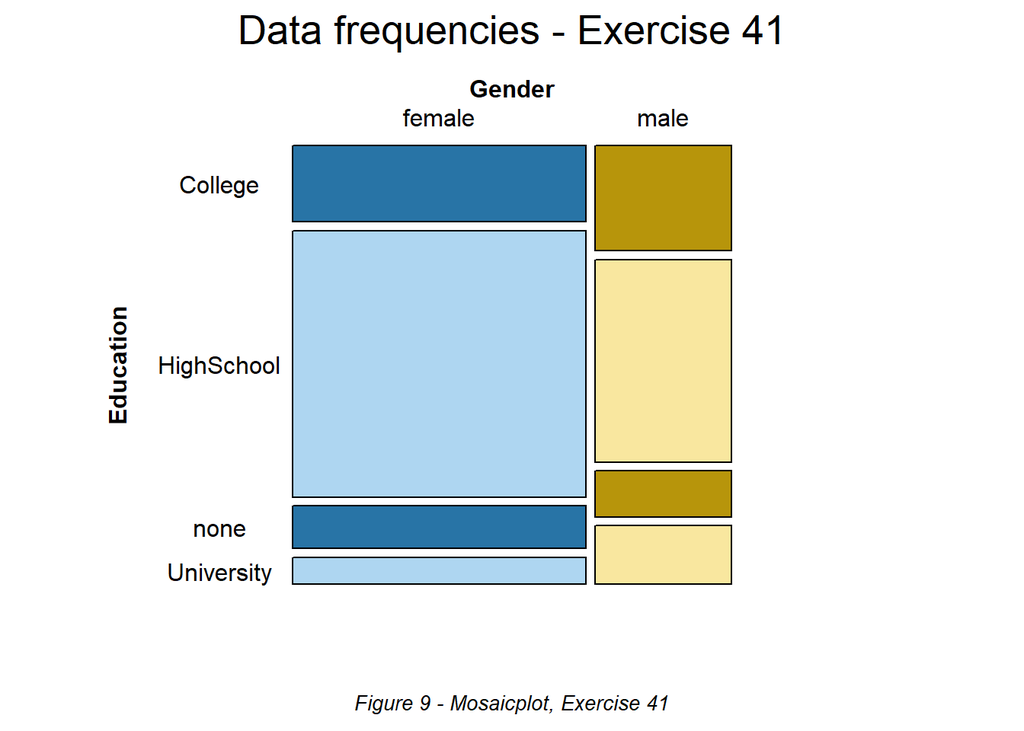

```r
vcd::mosaic(Data_Exc41, main = "Data frequencies - Exercise 41", sub = 'Figure 9 - Mosaicplot, Exercise 41', sub_gp = gpar(fontface = "italic",fontsize = 10), color = TRUE, shade = TRUE, direction=c("v","h"), gp = gpar(fill=c('#2874A6', '#B7950B', '#AED6F1', '#F9E79F')), labeling= labeling_border(rot_labels = c(0),offset_varnames = c(0,4),offset_labels=c(left=1.5)))
```

### Hypotheses

| Null Hypothesis | Alternative Hypothesis |
| --- | --- |
| There is not connection between the highest level of education and gender. | There is a connection between the two variables ‘highest level of education’ and ‘gender’. |

```r
xchisq.test(Gender ~ Highest_level_of_education, data = ICM)
```

```
##
##  Pearson's Chi-squared test
##
## data:  x
## X-squared = 5.584, df = 3, p-value = 0.1337
##
##    25       88       14        9
## (28.02)  (81.33)  (14.35)  (12.30)
## [0.3255] [0.5476] [0.0086] [0.8861]
## <-0.571> < 0.740> <-0.093> <-0.941>
##
##    16       31        7        9
## (12.98)  (37.67)  ( 6.65)  ( 5.70)
## [0.7027] [1.1821] [0.0186] [1.9128]
## < 0.838> <-1.087> < 0.136> < 1.383>
##
## key:
##  observed
##  (expected)
##  [contribution to X-squared]
##  <Pearson residual>
```

## Exercise 42

Use the dataset ’ICM’.  
Is there an association between education and smoking?

```r
str(ICM)
```

```
## 'data.frame':    199 obs. of  23 variables:
##  $ ID                        : int  75 90 173 189 100 155 63 48 76 165 ...
##  $ Gender                    : chr  "female" "female" "female" "female" ...
##  $ Age                       : int  22 22 37 17 19 16 17 19 27 19 ...
##  $ Englishfluent             : chr  "yes" "yes" "yes" "yes" ...
##  $ Germanfluent              : chr  "no" "no" "yes" "yes" ...
##  $ Transport                 : chr  "PublicTransport" "PublicTransport" "Car" "Car" ...
##  $ Highest_level_of_education: chr  "College" "College" "University" "none" ...
##  $ Do_you_smoke              : chr  "No" "No" "No" "No" ...
##  $ Socialmediahours          : chr  "1.5-3hrs/day" "1.5-3hrs/day" "<1.5hrs/day" "1.5-3hrs/day" ...
##  $ Timewithfriends           : chr  "2-5hrs/week" "2-5hrs/week" "5-10hrs/week" "10-20hrs/week" ...
##  $ Pet                       : chr  "No" "No" "Yes" "Yes" ...
##  $ Siblings                  : chr  "Yes" "Yes" "No" "Yes" ...
##  $ Children                  : chr  "No" "No" "Yes" "No" ...
##  $ Relationshipstatus        : chr  "Relationship" "Relationship" "Relationship" "Single" ...
##  $ Activitieshours           : int  10 10 20 40 20 10 10 20 10 20 ...
##  $ NegativeMood              : num  NA NA NA 4 2.82 ...
##  $ PositiveMood              : num  NA NA NA 0 0.333 ...
##  $ Mentalhealth              : num  2.667 2.667 3.5 1 0.833 ...
##  $ Socialization             : num  NA NA NA 1 2.5 ...
##  $ Activity                  : num  2.8 2.8 3.4 3.2 1.2 2.6 1.6 1.8 1.2 0.4 ...
##  $ SocialSupport             : num  4 4 2.333 0.667 2.333 ...
##  $ Communication_open_direct : num  NA NA 3.38 3.62 3.15 ...
##  $ OHS                       : num  4.59 4.59 5.1 3.14 2.76 ...
```

```r
unique(ICM$Highest_level_of_education)
```

```
## [1] "College"    "University" "none"       "HighSchool"
```

### Data Visualization

```r
Data_Exc42 <- tally(~Highest_level_of_education | Do_you_smoke, data = ICM)
dimnames(Data_Exc42) <- list(Education = c("College", "HighSchool", "none", "University"), Smoking = c("No","Yes"))
kable(Data_Exc42)
```

|  | No | Yes |
| --- | --- | --- |
| College | 31 | 10 |
| HighSchool | 102 | 17 |
| none | 19 | 2 |
| University | 17 | 1 |

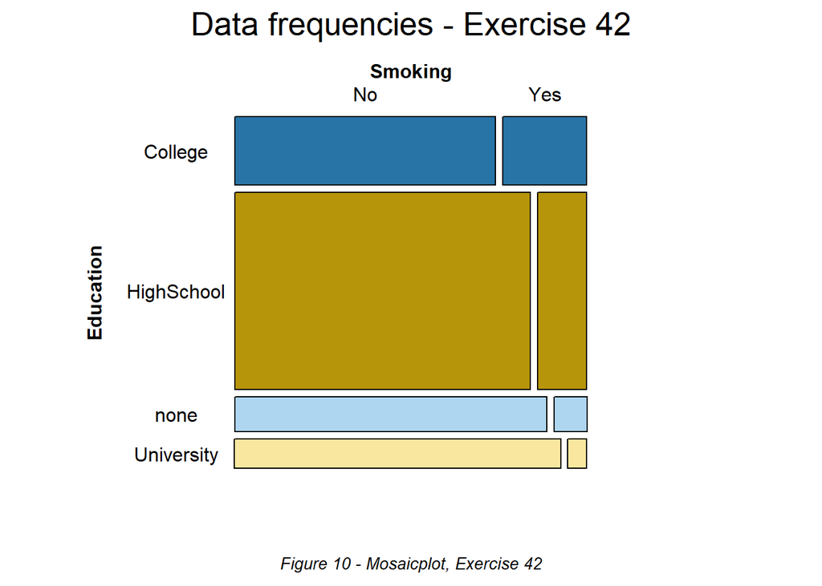

```r
vcd::mosaic(Data_Exc42, main = "Data frequencies - Exercise 42", sub = 'Figure 10 - Mosaicplot, Exercise 42', sub_gp = gpar(fontface = "italic",fontsize = 10), color = TRUE, shade = TRUE, direction=c("h","v"), gp = gpar(fill=c('#2874A6', '#B7950B', '#AED6F1', '#F9E79F')), labeling= labeling_border(rot_labels = c(0,0),offset_varnames = c(0,4),offset_labels=c(left=1.5)))
```

### Hypotheses

| Null Hypothesis | Alternative Hypothesis |
| --- | --- |
| There is not connection between the highest level of education and smoking behavior. | There is a connection between the two variables ‘highest level of education’ and ‘smoking behavior’. |

```r
xchisq.test(Highest_level_of_education ~ Do_you_smoke, data = ICM)
```

```
##
##  Pearson's Chi-squared test
##
## data:  x
## X-squared = 4.6163, df = 3, p-value = 0.2021
##
##    31       10
## ( 34.82) (  6.18)
## [0.4189] [2.3598]
## <-0.647> < 1.536>
##
##   102       17
## (101.06) ( 17.94)
## [0.0087] [0.0492]
## < 0.093> <-0.222>
##
##    19        2
## ( 17.83) (  3.17)
## [0.0762] [0.4293]
## < 0.276> <-0.655>
##
##    17        1
## ( 15.29) (  2.71)
## [0.1921] [1.0821]
## < 0.438> <-1.040>
##
## key:
##  observed
##  (expected)
##  [contribution to X-squared]
##  <Pearson residual>
```

## Exercise 43

Use the dataset ’ICM’.  
Is there an association between the transport used to get to work and the time spent with social media?

```r
str(ICM)
```

```
## 'data.frame':    199 obs. of  23 variables:
##  $ ID                        : int  75 90 173 189 100 155 63 48 76 165 ...
##  $ Gender                    : chr  "female" "female" "female" "female" ...
##  $ Age                       : int  22 22 37 17 19 16 17 19 27 19 ...
##  $ Englishfluent             : chr  "yes" "yes" "yes" "yes" ...
##  $ Germanfluent              : chr  "no" "no" "yes" "yes" ...
##  $ Transport                 : chr  "PublicTransport" "PublicTransport" "Car" "Car" ...
##  $ Highest_level_of_education: chr  "College" "College" "University" "none" ...
##  $ Do_you_smoke              : chr  "No" "No" "No" "No" ...
##  $ Socialmediahours          : chr  "1.5-3hrs/day" "1.5-3hrs/day" "<1.5hrs/day" "1.5-3hrs/day" ...
##  $ Timewithfriends           : chr  "2-5hrs/week" "2-5hrs/week" "5-10hrs/week" "10-20hrs/week" ...
##  $ Pet                       : chr  "No" "No" "Yes" "Yes" ...
##  $ Siblings                  : chr  "Yes" "Yes" "No" "Yes" ...
##  $ Children                  : chr  "No" "No" "Yes" "No" ...
##  $ Relationshipstatus        : chr  "Relationship" "Relationship" "Relationship" "Single" ...
##  $ Activitieshours           : int  10 10 20 40 20 10 10 20 10 20 ...
##  $ NegativeMood              : num  NA NA NA 4 2.82 ...
##  $ PositiveMood              : num  NA NA NA 0 0.333 ...
##  $ Mentalhealth              : num  2.667 2.667 3.5 1 0.833 ...
##  $ Socialization             : num  NA NA NA 1 2.5 ...
##  $ Activity                  : num  2.8 2.8 3.4 3.2 1.2 2.6 1.6 1.8 1.2 0.4 ...
##  $ SocialSupport             : num  4 4 2.333 0.667 2.333 ...
##  $ Communication_open_direct : num  NA NA 3.38 3.62 3.15 ...
##  $ OHS                       : num  4.59 4.59 5.1 3.14 2.76 ...
```

```r
unique(ICM$Transport)
```

```
## [1] "PublicTransport" "Car"             "Walk"            "Bicycle"
```

```r
unique(ICM$Socialmediahours)
```

```
## [1] "1.5-3hrs/day" "<1.5hrs/day"  "3-5hrs/day"   ">5hours/day"
```

### Data Visualization

```r
Data_Exc43 <- tally(~Transport | Socialmediahours, data = ICM)
dimnames(Data_Exc43) <- list(Transport = c("PublicTransport","Car","Walk","Bicycle"), Socialmediahours = c("1.5-3","<1.5","3-5",">5" ))
kable(Data_Exc43)
```

|  | 1.5-3 | <1.5 | 3-5 | >5 |
| --- | --- | --- | --- | --- |
| PublicTransport | 5 | 1 | 8 | 0 |
| Car | 37 | 1 | 31 | 10 |
| Walk | 13 | 6 | 27 | 18 |
| Bicycle | 9 | 2 | 22 | 9 |

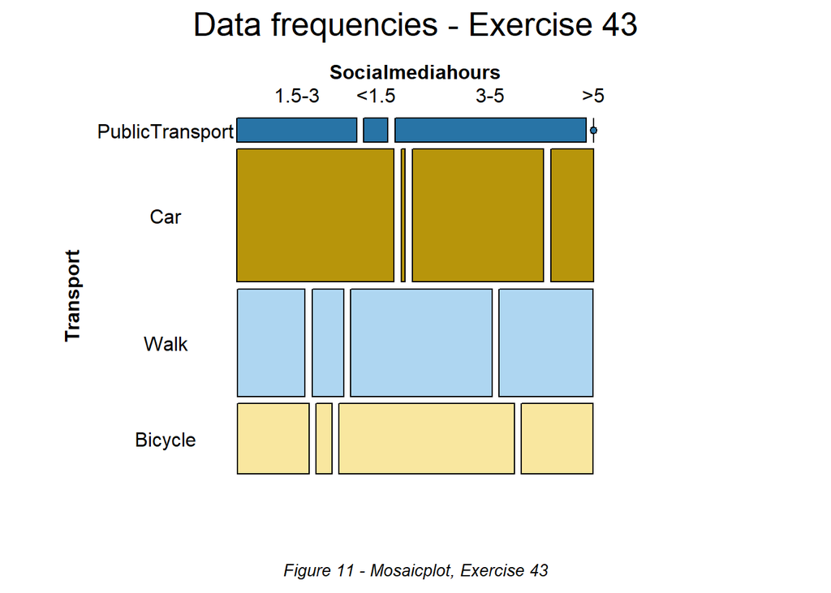

```r
vcd::mosaic(Data_Exc43, main = "Data frequencies - Exercise 43", sub = 'Figure 11 - Mosaicplot, Exercise 43', sub_gp = gpar(fontface = "italic",fontsize = 10), color = TRUE, shade = TRUE, direction=c("h","v"), gp = gpar(fill=c('#2874A6', '#B7950B', '#AED6F1', '#F9E79F')), labeling= labeling_border(rot_labels = c(0,0),offset_varnames = c(0,5),offset_labels=c(0,2)))
```

### Hypotheses

| Null Hypothesis | Alternative Hypothesis |
| --- | --- |
| There is not connection between the transport used to get to work and the hours spent using social media. | There is a connection between the two variables ‘transport used to get to work’ and ‘hours spent using social media’. |

```r
xchisq.test(Transport ~ Socialmediahours, data = ICM)
```

```
##
##  Pearson's Chi-squared test
##
## data:  x
## X-squared = 23.478, df = 9, p-value = 0.005208
##
##     5        1        8        0
## ( 4.50)  ( 0.70)  ( 6.19)  ( 2.60)
## [0.0550] [0.1249] [0.5286] [2.6030]
## < 0.234> < 0.353> < 0.727> <-1.613>
##
##    37        1       31       10
## (25.41)  ( 3.97)  (34.93)  (14.69)
## [5.2897] [2.2217] [0.4432] [1.4965]
## < 2.300> <-1.491> <-0.666> <-1.223>
##
##    13        6       27       18
## (20.58)  ( 3.22)  (28.30)  (11.90)
## [2.7936] [2.4098] [0.0599] [3.1275]
## <-1.671> < 1.552> <-0.245> < 1.768>
##
##     9        2       22        9
## (13.51)  ( 2.11)  (18.57)  ( 7.81)
## [1.5042] [0.0058] [0.6324] [0.1816]
## <-1.226> <-0.076> < 0.795> < 0.426>
##
## key:
##  observed
##  (expected)
##  [contribution to X-squared]
##  <Pearson residual>
```

## Exercise 46

Use the dataset ’OHS 2020 paired’.  
Is there a statistically significant difference between the happiness of the students between the three time points?

```r
OHS_2020_paired<-read.delim("C:\\_Privat\\_MSC_\\Skripten und Hü\\Statistics\\HW\\Datasets-20221012\\OHS_2020_paired.txt",stringsAsFactors=F)
```

```r
str(OHS_2020_paired)
```

```
## 'data.frame':    21 obs. of  4 variables:
##  $ Name : chr  "Jennifer" "Tanja" "Heike" "David" ...
##  $ OHS_1: num  NA 4.6 3.7 4.6 4.2 4.6 5 4.3 5.1 5.2 ...
##  $ OHS_2: num  4.8 4.8 3.8 5 4.6 5.4 4.4 5.1 4.8 5.8 ...
##  $ OHS_3: num  5.2 NA 4.5 4.9 4.6 5.3 4.1 4.9 4.6 5.9 ...
```

```r
inspect(OHS_2020_paired)
```

```
##
## categorical variables:
##   name     class levels  n missing
## 1 Name character     17 21       0
##                                    distribution
## 1 Denise (9.5%), Florian (9.5%) ...
##
## quantitative variables:
##    name   class min   Q1 median  Q3 max     mean        sd  n missing
## 1 OHS_1 numeric 3.7 4.55   4.75 5.1 5.6 4.770000 0.5161599 20       1
## 2 OHS_2 numeric 3.8 4.70   4.90 5.4 5.8 4.928571 0.5514915 21       0
## 3 OHS_3 numeric 4.1 4.60   4.90 5.3 5.9 4.968421 0.4546704 19       2
```

```r
head(OHS_2020_paired)
```

|  | Name | OHS_1 | OHS_2 | OHS_3 |
| --- | --- | --- | --- | --- |
| 1 | Jennifer | NA | 4.8 | 5.2 |
| 2 | Tanja | 4.6 | 4.8 | NA |
| 3 | Heike | 3.7 | 3.8 | 4.5 |
| 4 | David | 4.6 | 5.0 | 4.9 |
| 5 | Florian | 4.2 | 4.6 | 4.6 |
| 6 | Denise | 4.6 | 5.4 | 5.3 |

Remove pairs having null values

```r
OHS_1_2 <- data.frame(subset(OHS_2020_paired, !is.na(OHS_1) & !is.na(OHS_2)))
OHS_1_2
```

|  | Name | OHS_1 | OHS_2 | OHS_3 |
| --- | --- | --- | --- | --- |
| 2 | Tanja | 4.6 | 4.8 | NA |
| 3 | Heike | 3.7 | 3.8 | 4.5 |
| 4 | David | 4.6 | 5.0 | 4.9 |
| 5 | Florian | 4.2 | 4.6 | 4.6 |
| 6 | Denise | 4.6 | 5.4 | 5.3 |
| 7 | Carmen | 5.0 | 4.4 | 4.1 |
| 8 | Florian | 4.3 | 5.1 | 4.9 |
| 9 | Johannes | 5.1 | 4.8 | 4.6 |
| 10 | Selina | 5.2 | 5.8 | 5.9 |
| 11 | Paul | 4.9 | 4.7 | 4.7 |

[output cut: 10 more lines]

```r
OHS_2_3 <- data.frame(subset(OHS_2020_paired, !is.na(OHS_2) & !is.na(OHS_3)))
OHS_2_3
```

|  | Name | OHS_1 | OHS_2 | OHS_3 |
| --- | --- | --- | --- | --- |
| 1 | Jennifer | NA | 4.8 | 5.2 |
| 3 | Heike | 3.7 | 3.8 | 4.5 |
| 4 | David | 4.6 | 5.0 | 4.9 |
| 5 | Florian | 4.2 | 4.6 | 4.6 |
| 6 | Denise | 4.6 | 5.4 | 5.3 |
| 7 | Carmen | 5.0 | 4.4 | 4.1 |
| 8 | Florian | 4.3 | 5.1 | 4.9 |
| 9 | Johannes | 5.1 | 4.8 | 4.6 |
| 10 | Selina | 5.2 | 5.8 | 5.9 |
| 11 | Paul | 4.9 | 4.7 | 4.7 |

[output cut: 9 more lines]

```r
OHS_1_3 <- data.frame(subset(OHS_2020_paired, !is.na(OHS_1) & !is.na(OHS_3)))
OHS_1_3
```

|  | Name | OHS_1 | OHS_2 | OHS_3 |
| --- | --- | --- | --- | --- |
| 3 | Heike | 3.7 | 3.8 | 4.5 |
| 4 | David | 4.6 | 5.0 | 4.9 |
| 5 | Florian | 4.2 | 4.6 | 4.6 |
| 6 | Denise | 4.6 | 5.4 | 5.3 |
| 7 | Carmen | 5.0 | 4.4 | 4.1 |
| 8 | Florian | 4.3 | 5.1 | 4.9 |
| 9 | Johannes | 5.1 | 4.8 | 4.6 |
| 10 | Selina | 5.2 | 5.8 | 5.9 |
| 11 | Paul | 4.9 | 4.7 | 4.7 |
| 12 | Markus | 4.4 | 4.9 | 5.3 |

[output cut: 8 more lines]

### Approach

[figure not shown]

[figure not shown]